# Modeling and Uncertainty

Building models for biological data

Kris Sankaran and Marothi Peter Letsoalo

Workshop materials are at:

https://elsherbini.github.io/durban-data-science-for-biology/

### Goals for this session

1. Distinguish between the “large” and “small” worlds of modeling.
2. Compare biostatistical models and explain when they apply.
3. Use R to estimate models and know how to explain the output.
4. Diagnose and address model failures .

## Discussions: discord

Ask questions at **#workshop-questions** on https://discord.gg/UDAsYTzZE.

[figure not shown]

# Part 1: What is a Model?

## Let’s start with a picture

- The plots below show IL-1a concentration from our workshop luminex dataset.
- Notice the variation across people and a possible treatment effect at the post-treatment visit.

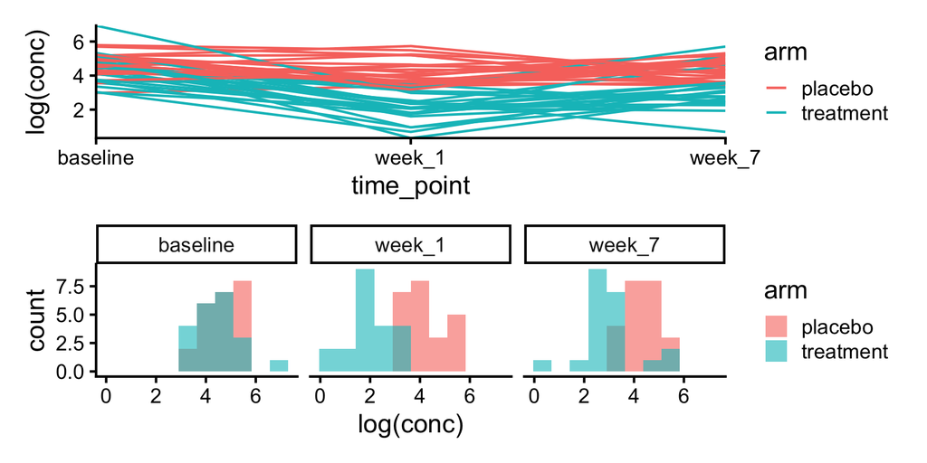

## Discussion

Imagine running the study again, keeping the recruitment and experimental protocols as similar as possible. Make two lists:

- Aspects of these plots that you think **will continue to be true** in the new experiment.
- Aspects of these plots that you think **will be different**.

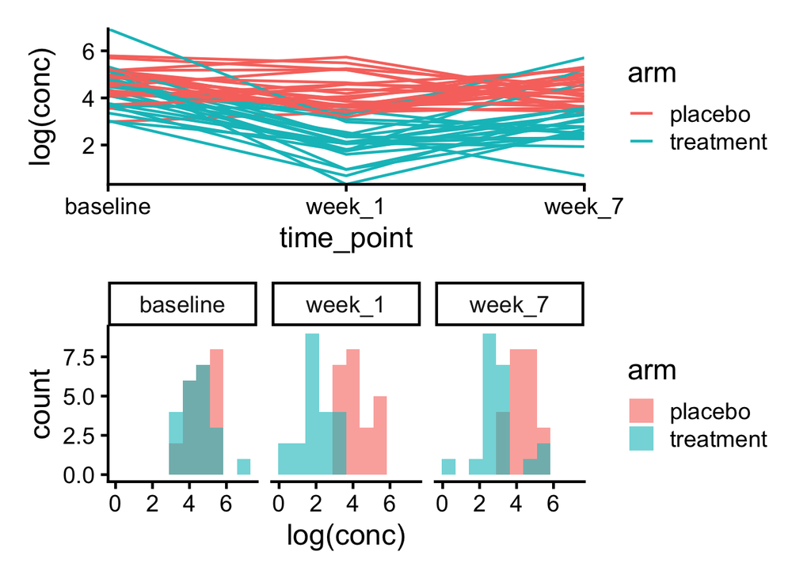

```r
p1 / p2
```

## A statistical model

> A statistical model is a simplified description of how the data were generated, the “data story.”
- Model parameters let us answer substantive scientific questions, like how a treatment affects outcomes.
- We observe just one realization of the data generating process – things could have turned out differently.

## The data story

**Biology**

(true DGP)

**Experiment**

(one realization)

**Model**

(small-world story)

## Large vs. small worlds

**Large world**

- Where the data were actually gathered
- Complex, influenced by factors we never observed
- Hard to carry out controlled interventions

**Small world**

- Inside the statistical model
- Logically consistent with precisely stated assumptions
- Allows hypothetical interventions and quantifies uncertainty

. . .

There will always be a gap between the two worlds. That gap is itself a source of uncertainty not captured by the model.

## Modeling Checklist

1. **Biological Question.** A good model should clarify our thinking about a real phenomenon and not be made for the sake of modeling.
2. **Plot the Data.** What does the outcome look like? Do you notice relationships with other variables?
3. **Working Assumptions.** Make a small-world story for how the data were generated. This is the initial statistical model.
4. **Model Checks.** Use simulation and diagnostics to check whether the model captures patterns we see in the real data.
5. **Revised Models.** Revise until the model provides a good match. Use this to answer the original question.

# Part 2: A Tour through the Model Zoo

## Why a zoo?

Each type of statistical model is designed for a different kind of data or biological question.

. . .

Knowing all the “species” of model will let you adapt to whatever data or questions you encounter.

. . .

Today’s tour:

- **Bernoulli / Binomial** — binary outcomes
- **Poisson / Negative Binomial** — count outcomes
- **Linear regression** — continuous outcomes
- **Survival models** — time-to-event outcomes
- **Variations** — multiple predictors, mixed effects, interactions

## Bernoulli and Binomial Models

These models apply when outcomes fall into **two groups**.

- Infected vs. not infected
- Responder vs. non-responder
- Alive vs. dead

The **Bernoulli** is for *individual outcomes*, the **Binomial** applies to their *totals*

## The data story

- Each person’s characteristics shift the outcome probabilities
- For example: *more social contact → higher probability of infection.*

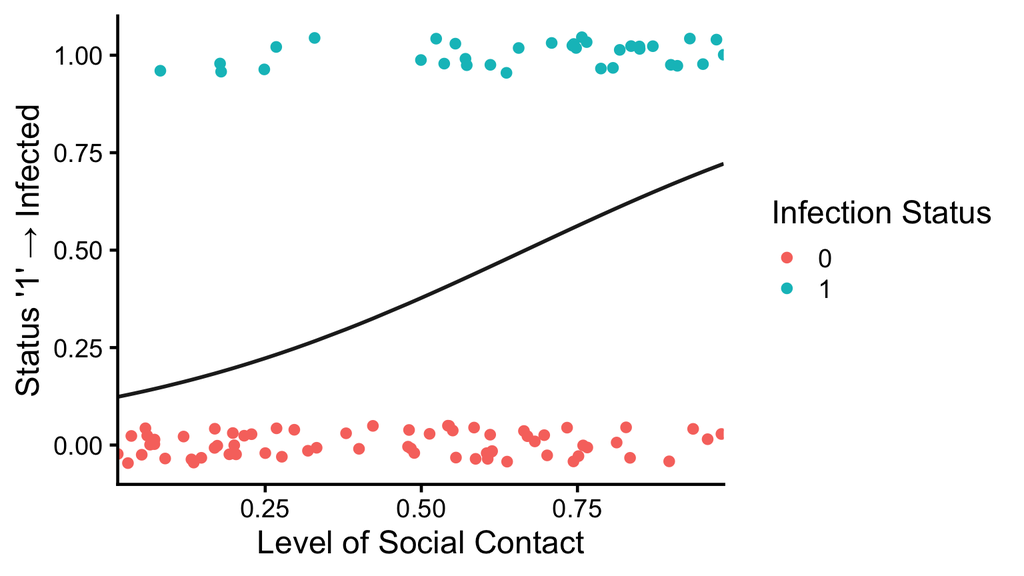

## Infection data

- Each row corresponds to a person
- The outcome takes one of two values

```r
infections |>
    select(sample_id, social_contact, infected)
```

```
## # A tibble: 100 × 3
##    sample_id social_contact infected
##    <chr>              <dbl>    <dbl>
##  1 sample_1          0.748         1
##  2 sample_2          0.379         0
##  3 sample_3          0.483         0
##  4 sample_4          0.813         0
##  5 sample_5          0.670         0
##  6 sample_6          0.400         0
##  7 sample_7          0.0899        0
##  8 sample_8          0.611         1
##  9 sample_9          0.935         0
## 10 sample_10         0.849         1
## # ℹ 90 more rows
```

## Fitting with `glm`

The `glm` function has three arguments:

- `formula`: written `y ~ x`, this relates outcome `y` to **covariates** `x`
- `family`: the type of model (depends on the data type of the outcome)
- `data`: a `data.frame` containing the columns named in `formula`

## Bernoulli fit

```r
fit <- glm(infected ~ social_contact, family = binomial(), data = infections)
modelsummary(fit, shape = term ~ statistic, gof_map = NA)
```

|  | (1) Est. | (1) S.E. |
| --- | --- | --- |
| (Intercept) | -2.370 | 0.574 |
| social_contact | 3.093 | 0.891 |

We wrote `family = binomial()`, but since `infected` is 0/1, the code knows to run a Bernoulli model.

## Interpreting the fit

At social contact level `x`, the probability of infection is `≈ plogis(-2.37 + 3.09x)`

```r
plogis(-2.37)              # social contact = 0
```

```
## [1] 0.08548914
```

```r
plogis(-2.37 + 0.5 * 3.09) # social contact = 0.5
```

```
## [1] 0.3047033
```

```r
plogis(-2.37 + 1 * 3.09)   # social contact = 1
```

```
## [1] 0.672607
```

This is the model often called logistic regression, after the inverse logistic function (`plogis`).

## Aggregated (Binomial) data

If we only see **totals within categories**, then we can use a Binomial model.

```r
infections_totals
```

```
## # A tibble: 3 × 4
##   social_level not_infected infected total
##   <fct>               <dbl>    <dbl> <dbl>
## 1 low                    29        6    35
## 2 medium                 20        9    29
## 3 high                   17       19    36
```

## Aggregated (Binomial) data

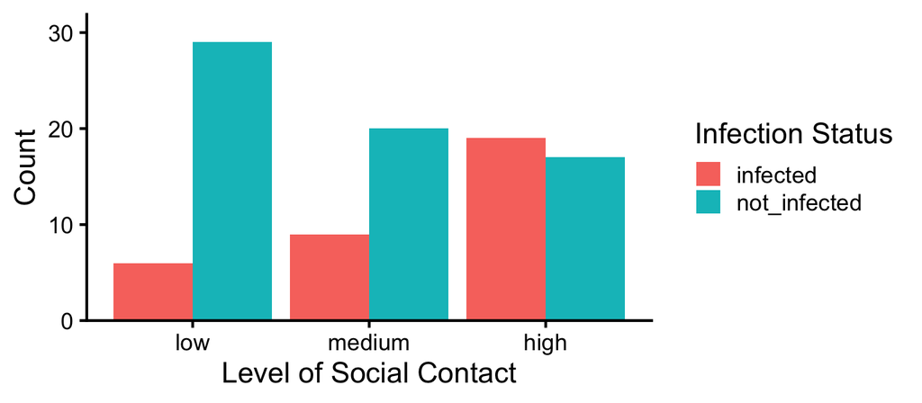

## Fitting the Binomial

For group-level counts, the formula’s left-hand side becomes a proportion, and we add `weights` to reflect group totals.

```r
fit <- glm(infected / total ~ social_level, family = binomial(),
           weights = total, data = infections_totals)
modelsummary(fit, shape = term ~ statistic, gof_map = NA)
```

|  | (1) Est. | (1) S.E. |
| --- | --- | --- |
| (Intercept) | -1.576 | 0.448 |
| social_levelmedium | 0.777 | 0.602 |
| social_levelhigh | 1.687 | 0.559 |

## Poisson and Negative Binomial Models

These models apply to **count data**.

The Poisson arises whenever we count events spread uniformly across space and time — like raindrops landing on a window during a minute of rain.

## Poisson and Negative Binomial Models

Many biological counts have this flavor:

- Transcript counts in a cell
- Mutation count along a segment of the genome
- Infection count within a county

## Outbreak counts vs. distance

Counts can depend on sample characteristics, like more infections in counties closer to the outbreak epicenter.

The mean parameter is called the **Poisson rate**.

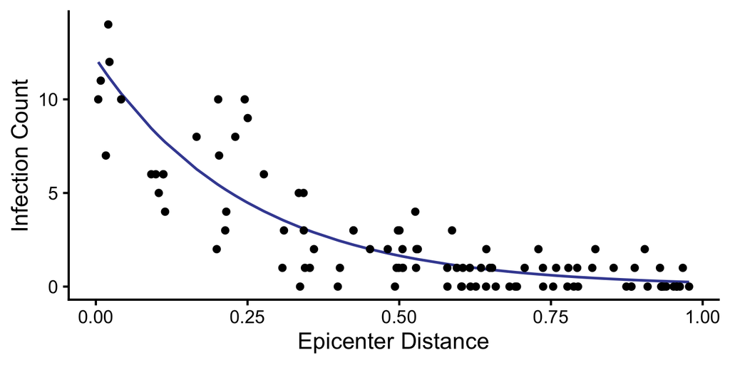

## Outbreak counts vs. distance

Counts can depend on sample characteristics, like more infections in counties closer to the outbreak epicenter.

The mean parameter is called the **Poisson rate**.

```r
outbreak |>
    select(sample_id, epicenter_distance, infected)
```

```
## # A tibble: 100 × 3
##    sample_id epicenter_distance infected
##    <chr>                  <dbl>    <dbl>
##  1 sample_1               0.952        0
##  2 sample_2               0.213        3
##  3 sample_3               0.498        3
##  4 sample_4               0.307        1
##  5 sample_5               0.888        1
##  6 sample_6               0.605        1
##  7 sample_7               0.930        1
##  8 sample_8               0.737        0
##  9 sample_9               0.399        0
## 10 sample_10              0.104        5
## # ℹ 90 more rows
```

## Fitting the Poisson

```r
fit <- glm(infected ~ epicenter_distance, family = poisson(), data = outbreak)
modelsummary(fit, shape = term ~ statistic, gof_map = NA)
```

|  | (1) Est. | (1) S.E. |
| --- | --- | --- |
| (Intercept) | 2.415 | 0.095 |
| epicenter_distance | -3.893 | 0.273 |

Output is on the **log scale** — interpret after exponentiation.

## Interpreting the fit

- `x = 0` $\implies$ `exp(2.4) ≈ 11.0`
- `x = 0.5` $\implies$ `exp(2.4 − 0.5 × 3.9) ≈ 1.6`

```r
modelsummary(fit, shape = term ~ statistic, gof_map = NA)
```

|  | (1) Est. | (1) S.E. |
| --- | --- | --- |
| (Intercept) | 2.415 | 0.095 |
| epicenter_distance | -3.893 | 0.273 |

## Interpreting the fit

- `x = 0` $\implies$ `exp(2.4) ≈ 11.0`
- `x = 0.5` $\implies$ `exp(2.4 − 0.5 × 3.9) ≈ 1.6`

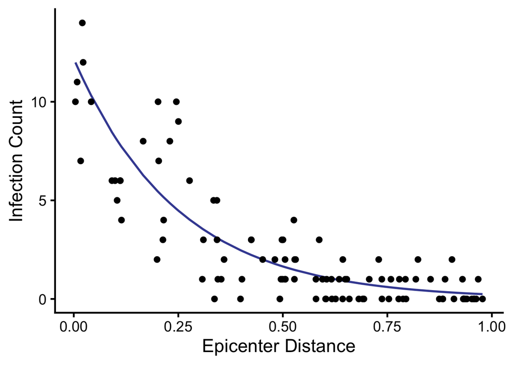

```r
ggplot(outbreak, aes(epicenter_distance)) +
    geom_line(aes(y = mean), col = "#414ca1", linewidth = 1) +
    geom_point(aes(y = infected), size = 2) +
    labs(x = "Epicenter Distance", y = "Infection Count")
```

## Overdispersion

Often unmeasured factors influence the rates, making the data more heterogeneous than the Poisson can handle.

- E.g., infection might depend not only on distance but on unknown, county-specific population densities.

The **negative binomial** addresses this — it arises as a mixture of Poissons with similar but slightly different rates.

## Negative binomial data

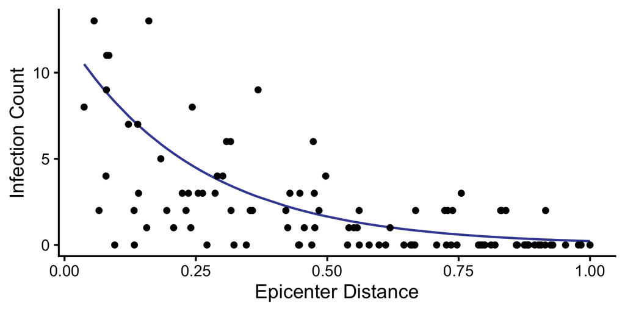

The blue mean line is unchanged, but counts at a given distance are more spread out.

## Fitting with `glm.nb`

`glm` doesn’t provide a negative binomial model, but `glm.nb` from the **MASS** package does. The syntax is the same as before.

```r
fit <- glm.nb(infected ~ epicenter_distance, data = outbreak_nb)
modelsummary(fit, shape = term ~ statistic, gof_map = NA)
```

|  | (1) Est. | (1) S.E. |
| --- | --- | --- |
| (Intercept) | 2.166 | 0.201 |
| epicenter_distance | -3.649 | 0.447 |

## Linear Regression Models

Linear regression applies when the response is **continuous**. For example:

- Antibody titre
- CRP concentration

The model assumes random Gaussian error around a mean value that depends on the inputs.

## Antibody titre vs age

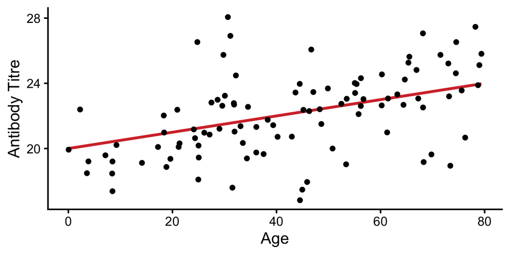

## Fitting with `lm`

Same inputs as `glm`, but no `family`.

```r
fit <- lm(antibody ~ age, data = antibody)
modelsummary(fit, shape = term ~ statistic, gof_map = NA)
```

|  | (1) Est. | (1) S.E. |
| --- | --- | --- |
| (Intercept) | 19.577 | 0.495 |
| age | 0.058 | 0.010 |

Predicted titre at age $x$: $19.6 + 0.058\,x$.

E.g. at age 10: $19.6 + 0.58 \approx 20.18$.

## Why Gaussian errors?

The **Central Limit Theorem**: the average of many small, independent effects tends toward a Gaussian distribution.

Here we’re implicitly assuming many small, independent factors — *besides age* — that perturb the observed antibody measurement.

# Survival Models

## When do they apply?

Survival models describe **whether and when an event occurs**.

- Time until heart attack
- Time until loan default
- Time until HIV acquisition

If the event doesn’t happen during the study, the participant’s response is called **censored**.

## The outcome has *two* parts

Unlike the other models, the survival outcome is *two* numbers:

- `time` — when the event was observed (or the study ended)
- `status` — whether the event happened (`1`) or was censored (`0`)

## Example: HIV acquisition

A 2-year study tracking participants on drug vs. control. Some have an event (triangles), some are censored.

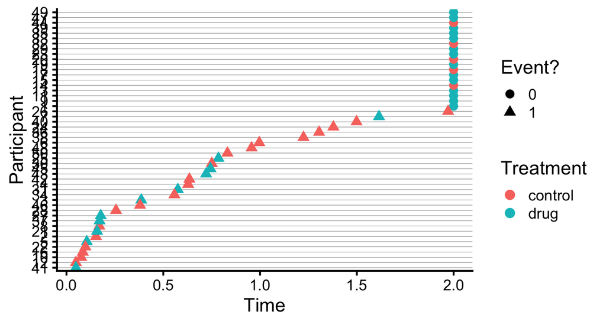

## The Cox proportional hazards model

The most popular survival model.

- During any time interval, anyone who hasn’t yet had an event is **at risk**.
- Covariates can change the relative risk (the **“hazard”**) of the event.
- A covariate shifts the hazard by the same factor at all times → *proportional* hazards.

## Fitting `coxph`

```r
fit <- coxph(Surv(time, status) ~ treatment, data = surv_data)
modelsummary(fit, shape = term ~ statistic, gof_map = NA)
```

|  | (1) Est. | (1) S.E. |
| --- | --- | --- |
| treatmentdrug | -0.838 | 0.378 |

The model output shows how each covariate **rescales the hazard**.

## When PH might fail

🤔 Can you think of an example where the proportional hazards assumption **does not hold**?

*Hint:* What if a drug was not effective immediately after treatment start, but required several weeks to reach its full effect?